# p8105_hw3_gw2383

Guojing Wu

2018/10/7

## Problem 1

### data cleaning

```r
brfss_df =
  p8105.datasets::brfss_smart2010 %>%
  janitor::clean_names() %>% # cleaning
  rename(location_abbr = locationabbr, location_desc = locationdesc) %>% # format the variable name
  filter(topic == "Overall Health") %>% # focus on the “Overall Health” topic
  filter(response %in% c("Poor", "Fair", "Good", "Very good", "Excellent")) %>% # choose response
  arrange(response) # organize responses
```

### some questions

- In 2002, CT, FL, NC states were observed at 7 locations
- spaghetti plot

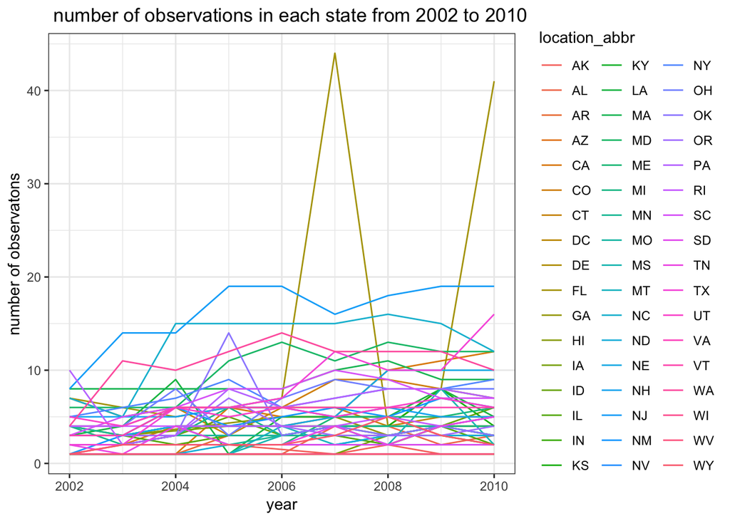

```r
brfss_df %>%
  distinct(year, location_abbr, location_desc) %>%
  group_by(year, location_abbr) %>%
  summarise(n = n()) %>%
  ggplot(aes(x = year, y = n, group = location_abbr, color = location_abbr)) +
  geom_line() +
  labs(
    y = "number of observatons",
    title = " number of observations in each state from 2002 to 2010"
  ) +
  theme_bw()
```

- a table of mean and standard deviation

```r
brfss_df %>%
  filter(year %in% c(2002, 2006, 2010) & location_abbr == "NY" & response == "Excellent") %>%
  group_by(year) %>%
  summarise(mean_exc = mean(data_value),
            sd_exc = sd(data_value)) %>%
   knitr::kable(digits = 1)
```

| year | mean_exc | sd_exc |
| --- | --- | --- |
| 2002 | 24.0 | 4.5 |
| 2006 | 22.5 | 4.0 |
| 2010 | 22.7 | 3.6 |

- a five-panel plot

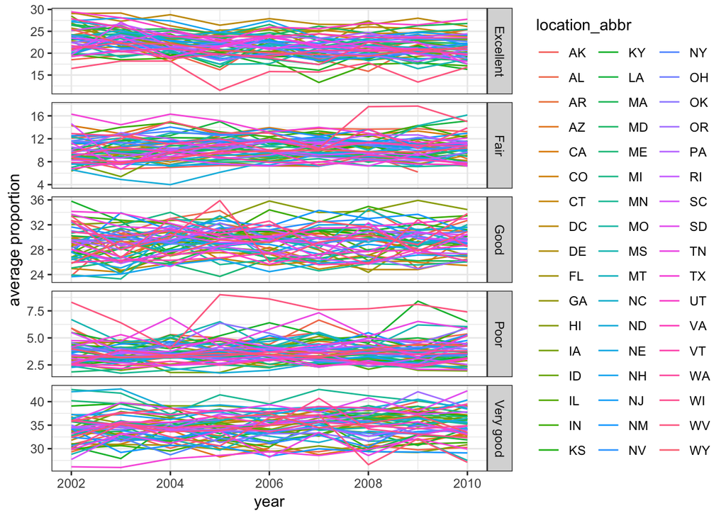

```r
brfss_df %>%
  group_by(year, location_abbr, response) %>%
  summarise(mean_prop = mean(data_value)) %>%
  ggplot(aes(x = year, y = mean_prop, group = location_abbr, color = location_abbr)) +
  geom_line() +
  labs(y = "average proportion") +
  facet_grid(response ~ ., scales = "free") + # ploting vertically and without the same axis scaling
  theme_bw()
```

## Problem 2

```r
insta_df = p8105.datasets::instacart %>%
  janitor::clean_names()
```

### short description

There are 15 variables and 1384617 observations in this dataset. It contains details of every order: like `user id`: customer identifier, `order id`: order identifier, `product id`: product identifier, `product name`, `reordered`: whether it’s reordered or not, when it was ordered (assume 0 was assigned to Sunday). Also, in the local store, there are 21 departments.

```r
insta_df %>% select(user_id, order_id, product_id, product_name, reordered, order_dow) %>% head(10) %>% knitr::kable()
```

| user_id | order_id | product_id | product_name | reordered | order_dow |
| --- | --- | --- | --- | --- | --- |
| 112108 | 1 | 49302 | Bulgarian Yogurt | 1 | 4 |
| 112108 | 1 | 11109 | Organic 4% Milk Fat Whole Milk Cottage Cheese | 1 | 4 |
| 112108 | 1 | 10246 | Organic Celery Hearts | 0 | 4 |
| 112108 | 1 | 49683 | Cucumber Kirby | 0 | 4 |
| 112108 | 1 | 43633 | Lightly Smoked Sardines in Olive Oil | 1 | 4 |
| 112108 | 1 | 13176 | Bag of Organic Bananas | 0 | 4 |
| 112108 | 1 | 47209 | Organic Hass Avocado | 0 | 4 |
| 112108 | 1 | 22035 | Organic Whole String Cheese | 1 | 4 |
| 79431 | 36 | 39612 | Grated Pecorino Romano Cheese | 0 | 6 |
| 79431 | 36 | 19660 | Spring Water | 1 | 6 |

### some questions

- There are 134 aisles in the store. fresh vegetables aisle is the most items ordered from.
- a plot that shows the number of items ordered in each aisle

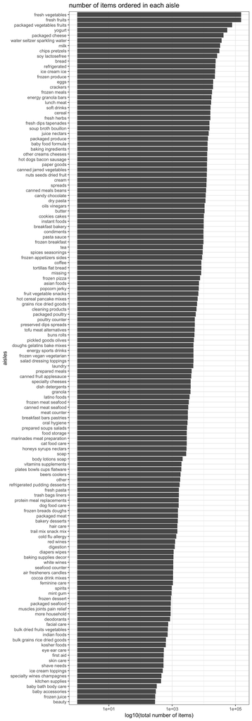

```r
# a function for sorting the factors so that aisles will be listed in descending way
reorder_size <- function(x) {
  factor(x, levels = names(sort(table(x))))
}

insta_df %>%
  select(aisle) %>%
  ggplot(aes(x = reorder_size(aisle))) +
  geom_bar() +
  scale_y_log10() +
  labs(x = "aisles",
       y = "log10(total number of items)",
       title = "number of items ordered in each aisle") +
  coord_flip()
```

- the most popular item:

```r
insta_df %>%
  filter(aisle %in% c("baking ingredients", "dog food care", "packaged vegetables fruits")) %>%
  group_by(aisle, product_name) %>%
  summarise(item_num = n()) %>%
  group_by(aisle) %>%
  mutate(item_rank = min_rank(desc(item_num))) %>% # calculate the rank
  filter(item_rank == 1) %>%
  knitr::kable(digits = 1)
```

| aisle | product_name | item_num | item_rank |
| --- | --- | --- | --- |
| baking ingredients | Light Brown Sugar | 499 | 1 |
| dog food care | Snack Sticks Chicken & Rice Recipe Dog Treats | 30 | 1 |
| packaged vegetables fruits | Organic Baby Spinach | 9784 | 1 |

- a table showing the mean hour of the day

for the consecutive number in order_dow, we assume 0 assign to Sunday, 1 assign to Monday and so on …

```r
insta_df %>%
  filter(product_name %in% c("Pink Lady Apples", "Coffee Ice Cream")) %>%
  select(product_name, order_dow, order_hour_of_day) %>%
  group_by(product_name, order_dow) %>%
  summarise(mean_hour = mean(order_hour_of_day)) %>%
  spread(key = order_dow, value = mean_hour) %>%
  rename(Sunday = "0", Monday = "1", Tuesday = "2", Wednesday = "3", Thursday = "4", Friday = "5", Saturday = "6") %>% # rename it to make it readable
  knitr::kable(digit = 1)
```

| product_name | Sunday | Monday | Tuesday | Wednesday | Thursday | Friday | Saturday |
| --- | --- | --- | --- | --- | --- | --- | --- |
| Coffee Ice Cream | 13.8 | 14.3 | 15.4 | 15.3 | 15.2 | 12.3 | 13.8 |
| Pink Lady Apples | 13.4 | 11.4 | 11.7 | 14.2 | 11.6 | 12.8 | 11.9 |

## Problem 3

```r
noaa_df = p8105.datasets::ny_noaa %>%
  janitor::clean_names()
```

### short description

There are 7 variables and 2595176 observations in this dataset. It contains details of everyday weatherr: like `id`: Weather station ID, `date`: Date of observation, `prcp`: Precipitation (tenths of mm), `snow`: Snowfall (mm), `snwd`: Snow depth (mm), `tmax`: aximum temperature (tenths of degrees C), `tmin`: Minimum temperature (tenths of degrees C).

Also we noticed that there are many NAs in the dataset, below are the table of the proportion of NAs in each column

```r
noaa_df %>%
  summarise(id_na = sum(is.na(id))/length(id),
            date_na = sum(is.na(date))/length(date),
            prcp_na = sum(is.na(prcp))/length(prcp),
            snow_na = sum(is.na(snow))/length(snow),
            snwd_na = sum(is.na(snwd))/length(snwd),
            tmax_na = sum(is.na(tmax))/length(tmax),
            tmin_na = sum(is.na(tmin))/length(tmin)
            ) %>%
  knitr::kable(digits = 3)
```

| id_na | date_na | prcp_na | snow_na | snwd_na | tmax_na | tmin_na |
| --- | --- | --- | --- | --- | --- | --- |
| 0 | 0 | 0.056 | 0.147 | 0.228 | 0.437 | 0.437 |

### some questions

- data cleaning and create separate variables for year, month, and day

Find the most commonly observed values for snowfall:

```r
noaa_df %>%
  separate(date, into = c("year", "month", "day"), sep = "-") %>% # separate the date
  rename(prcp_in_10_mm = prcp, snow_in_mm = snow, snwd_in_mm = snwd, tmax_in_celsius = tmax, tmin_in_celsius = tmin) %>%
  group_by(snow_in_mm) %>%
  summarise(observe_num = n()) %>%
  arrange(desc(observe_num)) %>% # decreasing order
  .[1,] %>%
  knitr::kable()
```

| snow_in_mm | observe_num |
| --- | --- |
| 0 | 2008508 |